# Water Column and Sediment Methanogens & Methanotrophs in FPV Ponds

## Sediment Methanogens

We want to see who is structuring the community within the sediments. In water column it is clearer that methanotrophs are, but what about in sediment communities?

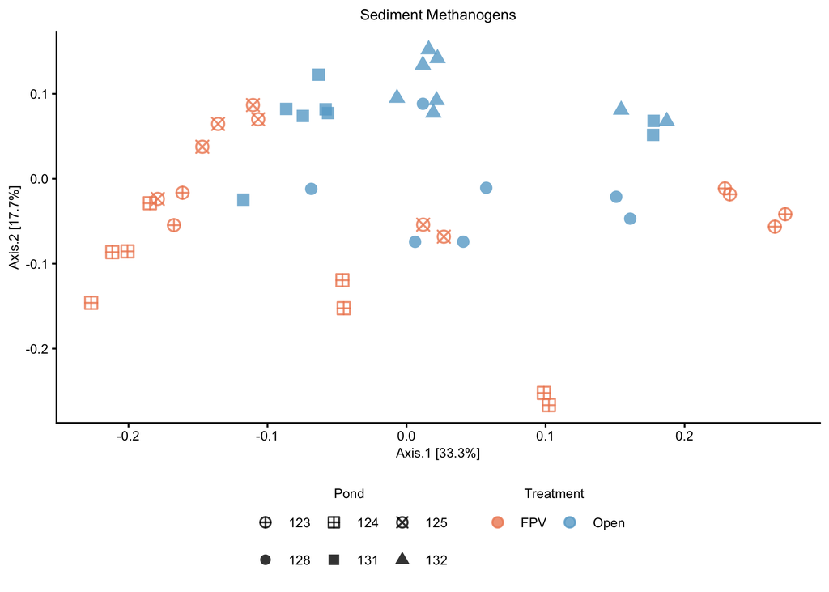

```r
# first lets filter our sed_ch4_cycler_physeq for methanogen or methanotroph
sed_methanogens_physeq <- subset_taxa(sed_ch4_cyclers_physeq, CH4_Cycler == "Methanogen") %>%
  prune_taxa(taxa_sums(.) > 0, .) # 150 ASVs


# 1. methanogens

# Calculate Bray-Curtis Dissimilarity
sed_methanogens_BC_pcoa <-
  ordinate(
    physeq = sed_methanogens_physeq,
    method = "PCoA",
    distance = "bray",
    binary = FALSE
  )

## NEW PLOT
#### Grab the data for the plot
sed_methanogen_ord_df <-
  plot_ordination(
  physeq = sed_methanogens_physeq,
  ordination = sed_methanogens_BC_pcoa,
  color = "solar_progress",
  shape = "Pond",
  justDF = TRUE)

# now lets mutate the columns
sed_methanogen_ord_df <- sed_methanogen_ord_df %>%
dplyr::mutate(
    solar_progress = recode(solar_progress, "FPV" = "FPV", "No FPV" = "Open")) # solar progress


### Now, plot Figure S3: SEDIMENT METHANOGENS
figS3_sed_methanogens_pcoa <-
  ggplot(data = sed_methanogen_ord_df,
       aes(x = Axis.1,
           y = Axis.2,
           color = solar_progress,
           shape = Pond)) +
  geom_point(size = 3, alpha = 0.8, stroke = 0.8) +
  scale_shape_manual(values = pond_shapes) +
  scale_color_manual(values = solar_colors) +
  labs(color = "Treatment",
       shape = "Pond",
       x = "Axis.1 [33.3%]",
       y = "Axis.2 [17.7%]",
       title = "Sediment Methanogens") +
  guides(
    color = guide_legend(
      title.position = "top",
      title.hjust = 0.5,
      override.aes = list(size = 2.5)),
    shape = guide_legend(
      nrow = 2,
      byrow = TRUE,
      title.position = "top",
      title.hjust = 0.5,
      override.aes = list(size = 2.5))
  ) +
  theme_classic() +
  theme(legend.position = "bottom",
        #legend.spacing = unit(0, "cm"),
        legend.box.background = element_blank(),
        legend.title = element_text(size = 8),
        legend.text = element_text(size = 8),
        plot.title = element_text(hjust = 0.5, size = 9, colour = "black"),
        axis.text.x = element_text(size = 8, colour = "black"),
        axis.text.y = element_text(size = 8, colour = "black"),
        axis.title.x = element_text(size = 8, colour = "black"),
        axis.title.y = element_text(size = 8, colour = "black"))

# Show the plot
figS3_sed_methanogens_pcoa
```

[figure not shown]

```r
figS1A_sed_methanogens_pcoaold <-
  plot_ordination(
  physeq = sed_methanogens_physeq,
  ordination = sed_methanogens_BC_pcoa,
  color = "solar_progress",
  shape = "Pond",
  title = "Sediment Methane Cyclers") +
  geom_point(size = 5, alpha = 0.5,
             aes(color = solar_progress, fill = solar_progress, shape = Pond)) +
  scale_color_manual(values = solar_colors) +
  scale_fill_manual(values = solar_colors) +
  scale_shape_manual(values = pond_shapes) +
  guides(color = "none",
         fill = "none",
         shape = "none") +
  theme_classic()
  # theme(
  # legend.position = c(0.82, 0.01),  # inside bottom-left
  # legend.justification = c(0, 0),  # anchor the legend's top-left corner there
  # legend.spacing = unit(0.1, "cm"),
  # legend.background = element_rect(color = NA, fill = NA),
  # legend.box.background = element_rect(size = 0.1, linetype = "solid", color = "black"),
  # legend.text = element_text(size = 6),
  # legend.margin = margin(2, 2, 2, 2))
figS1A_sed_methanogens_pcoaold
```

## Sediment Methanotrophs

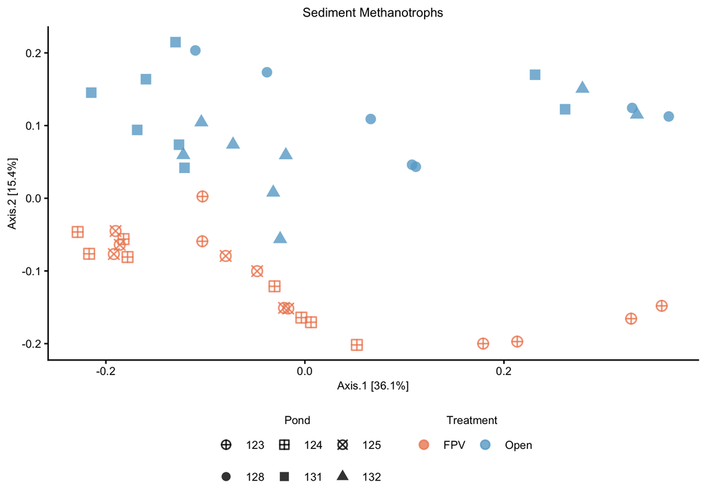

```r
# first lets filter our sed_ch4_cycler_physeq for methanogen or methanotroph
sed_methanotrophs_physeq <- subset_taxa(sed_ch4_cyclers_physeq, CH4_Cycler == "Methanotroph") %>%
  prune_taxa(taxa_sums(.) > 0, .) # 197 ASVs

# 2. methanotrophs

# Calculate Bray-Curtis Dissimilarity
sed_methanotroph_BC_pcoa <-
  ordinate(
    physeq = sed_methanotrophs_physeq,
    method = "PCoA",
    distance = "bray",
    binary = FALSE
  )


## NEW PLOT
#### Grab the data for the plot
sed_methanotroph_ord_df <-
  plot_ordination(
  physeq = sed_methanotrophs_physeq,
  ordination = sed_methanotroph_BC_pcoa,
  color = "solar_progress",
  shape = "Pond",
  justDF = TRUE)

# now lets mutate the columns
sed_methanotroph_ord_df <- sed_methanotroph_ord_df %>%
dplyr::mutate(
    solar_progress = recode(solar_progress, "FPV" = "FPV", "No FPV" = "Open")) # solar progress


### Now, plot Figure S1B: SEDIMENT METHANOTROPHS
figS3_sed_methanotroph_pcoa <-
  ggplot(data = sed_methanotroph_ord_df,
       aes(x = Axis.1,
           y = Axis.2,
           color = solar_progress,
           shape = Pond)) +
  geom_point(size = 3, alpha = 0.8, stroke = 0.8) +
  scale_shape_manual(values = pond_shapes) +
  scale_color_manual(values = solar_colors) +
  labs(color = "Treatment",
       shape = "Pond",
       x = "Axis.1 [36.1%]",
       y = "Axis.2 [15.4%]",
       title = "Sediment Methanotrophs") +
  guides(
    color = guide_legend(
      title.position = "top",
      title.hjust = 0.5,
      override.aes = list(size = 2.5)),
    shape = guide_legend(
      nrow = 2,
      byrow = TRUE,
      title.position = "top",
      title.hjust = 0.5,
      override.aes = list(size = 2.5))
  ) +
  theme_classic() +
  theme(legend.position = "bottom",
        #legend.spacing = unit(0, "cm"),
        legend.box.background = element_blank(),
        legend.title = element_text(size = 8),
        legend.text = element_text(size = 8),
        plot.title = element_text(hjust = 0.5, size = 9, colour = "black"),
        axis.text.x = element_text(size = 8, colour = "black"),
        axis.text.y = element_text(size = 8, colour = "black"),
        axis.title.x = element_text(size = 8, colour = "black"),
        axis.title.y = element_text(size = 8, colour = "black"))


# Show the plot
figS3_sed_methanotroph_pcoa
```

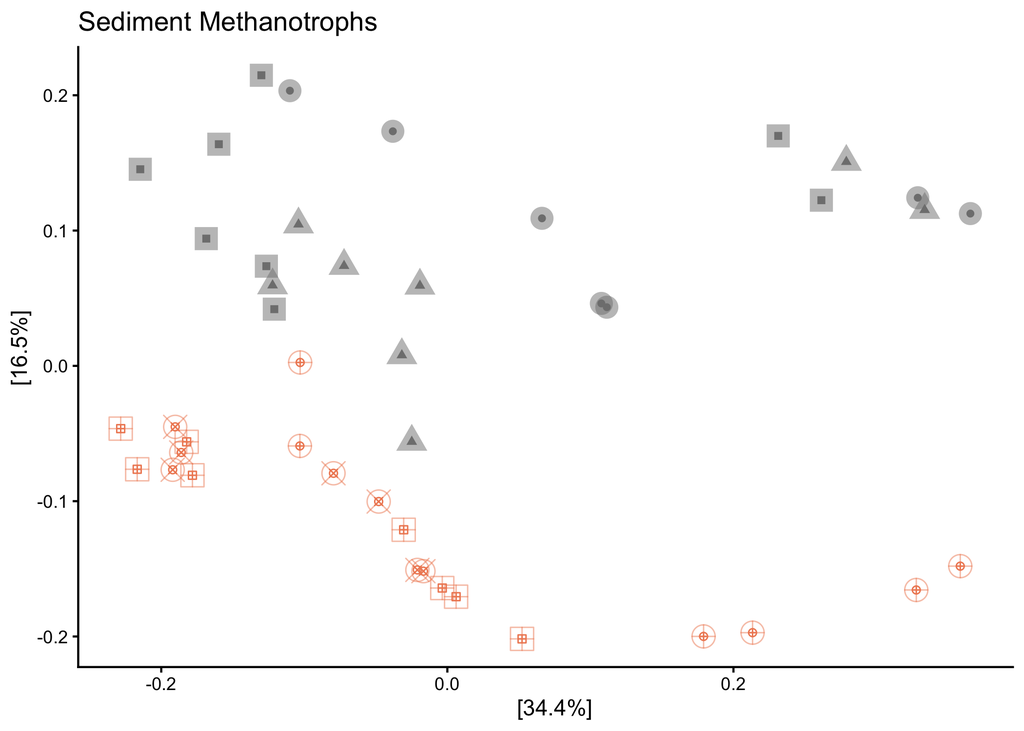

```r
# PCoA of sediments color by treatment shaped by pond
s2b_sed_troph <- plot_ordination(
  physeq = sed_methanotrophs_physeq,
  ordination = sed_methanotroph_BC_pcoa,
  color = "solar_progress",
  shape = "Pond",
  title = "Sediment Methanotrophs") +
  geom_point(size = 5, alpha = 0.5, aes(color = solar_progress, fill = solar_progress, shape = Pond)) +
  scale_color_manual(values = solar_colors) +
  scale_fill_manual(values = solar_colors) +
  scale_shape_manual(values = pond_shapes) +
  guides(color = "none",
         fill = "none",
         shape = "none")+
  theme_classic()
s2b_sed_troph
```

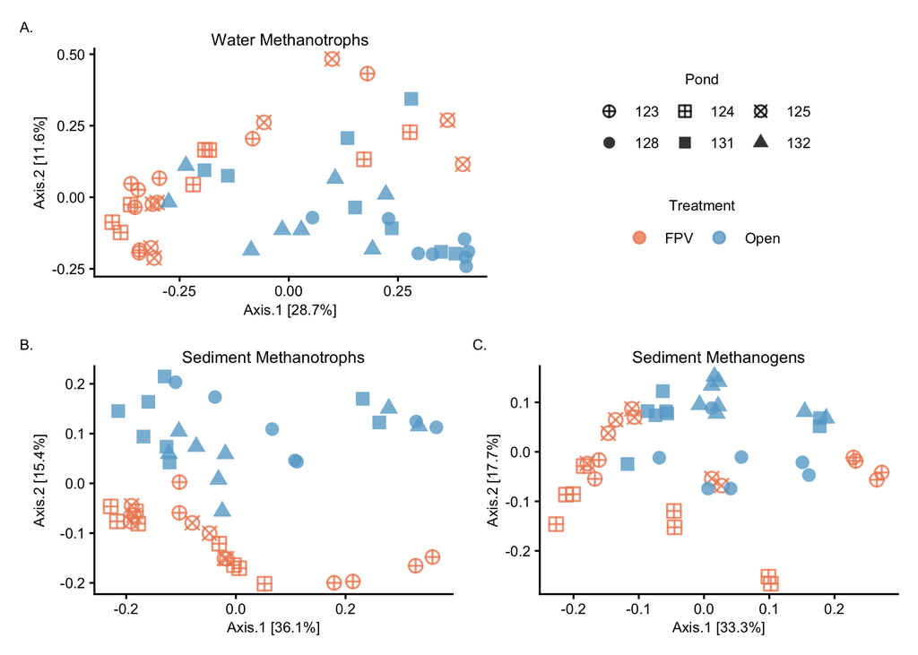

```r
# extract legend
leg <- cowplot::get_legend(
  figS3_sed_methanogens_pcoa +
    scale_color_manual(values = solar_colors, breaks = c("FPV", "Open")) +
    guides(
      color = guide_legend(title.hjust = 0.5, nrow = 1, byrow = TRUE,override.aes = list(size = 2.5)),  # horizontal Treatment
      shape = guide_legend(title.hjust = 0.5, nrow = 2, byrow = TRUE, override.aes = list(size = 2.5))   # optional
    ) +
    theme(legend.position = "right",
          legend.box = "vertical",
          legend.box.just = "center"))

leg_plot <- wrap_elements(leg)


# edit individual figures
pA <- figS3B_water_methanotroph_pcoa +
  labs(tag = "A.") +
  theme(legend.position = "none",
        plot.title = element_text(margin = margin(b = 0)))

pC <- figS3_sed_methanotroph_pcoa +
  labs(tag = "B.") +
  theme(legend.position = "none",
        plot.title = element_text(margin = margin(b = 0)))

pD <- figS3_sed_methanogens_pcoa +
  labs(tag = "C.") +
  theme(legend.position = "none",
        plot.title = element_text(margin = margin(b = 0)))

# plot together
plot_figS3 <-
  (pA + leg_plot) / (pC + pD) +
  plot_layout(widths = c(1, 1)) &
  theme(
    plot.tag = element_text(size = 8, colour = "black"))
plot_figS3
```

```r
# Now, actually save the plot
ggsave(plot_figS3, width = 6.5, height = 4.5, dpi = 300,
        filename = "figures/Fig_S4.png")
```

## Fig S3: PERMANOVA

PERMANOVA (Permutational Multivariate Analysis of Variance) is a non-parametric, permutation-based test used to compare groups of objects based on a distance matrix. The goal is to test the null hypothesis that the centroids and dispersion of groups are equivalent in the space defined by the dissimilarity measure.

### Sediment Methanogens

Here we are performing a PERMANOVA on the sediment methanogen and methanotrophs

```r
#1. methanogen
# calculate Bray-Curtis PERMANOVA using phyloseq distance
sed_gen_bray <- phyloseq::distance(sed_methanogens_physeq, method = "bray", binary = FALSE)


# pull out metadata
sed_methanogens_metadata <- sed_methanogens_physeq %>%
  sample_data() %>%
  data.frame()

# Permutational Multivariate Analysis of Variance Using Distance Matrices
# aka PERMANOVA using the adonis2 function from vegan


#1. Test the individual terms for significance
# Testing if the centroids of solar progress are different: significant p = 0.001 ***
adonis2(sed_gen_bray ~ solar_progress,
        data = sed_methanogens_metadata, by = "terms")
```

```
## Permutation test for adonis under reduced model
## Terms added sequentially (first to last)
## Permutation: free
## Number of permutations: 999
##
## adonis2(formula = sed_gen_bray ~ solar_progress, data = sed_methanogens_metadata, by = "terms")
##                Df SumOfSqs      R2      F Pr(>F)
## solar_progress  1  0.32179 0.12741 6.1324  0.001 ***
## Residual       42  2.20393 0.87259
## Total          43  2.52572 1.00000
## ---
## Signif. codes:  0 '***' 0.001 '**' 0.01 '*' 0.05 '.' 0.1 ' ' 1
```

```r
# Does pond matter? significant p = 0.001 ***
adonis2(sed_gen_bray ~ Pond,
        data = sed_methanogens_metadata, by = "terms")
```

```
## Permutation test for adonis under reduced model
## Terms added sequentially (first to last)
## Permutation: free
## Number of permutations: 999
##
## adonis2(formula = sed_gen_bray ~ Pond, data = sed_methanogens_metadata, by = "terms")
##          Df SumOfSqs      R2     F Pr(>F)
## Pond      5   1.1096 0.43932 5.955  0.001 ***
## Residual 38   1.4161 0.56068
## Total    43   2.5257 1.00000
## ---
## Signif. codes:  0 '***' 0.001 '**' 0.01 '*' 0.05 '.' 0.1 ' ' 1
```

```r
# Does date matter? significant p = 0.001 ***
adonis2(sed_gen_bray ~ as.factor(JDate),
        data = sed_methanogens_metadata, by = "terms")
```

```
## Permutation test for adonis under reduced model
## Terms added sequentially (first to last)
## Permutation: free
## Number of permutations: 999
##
## adonis2(formula = sed_gen_bray ~ as.factor(JDate), data = sed_methanogens_metadata, by = "terms")
##                  Df SumOfSqs      R2      F Pr(>F)
## as.factor(JDate)  3  0.56103 0.22213 3.8074  0.001 ***
## Residual         40  1.96469 0.77787
## Total            43  2.52572 1.00000
## ---
## Signif. codes:  0 '***' 0.001 '**' 0.01 '*' 0.05 '.' 0.1 ' ' 1
```

```r
#2. Test the terms together
# Now lets see the effect of each pond by date_collected and solar progress
sed_methanogens_permanova <-
  adonis2(sed_gen_bray ~ solar_progress * Pond * JDate,
          data = sed_methanogens_metadata, by = "terms");

# Show the results!
sed_methanogens_permanova
```

```
## Permutation test for adonis under reduced model
## Terms added sequentially (first to last)
## Permutation: free
## Number of permutations: 999
##
## adonis2(formula = sed_gen_bray ~ solar_progress * Pond * JDate, data = sed_methanogens_metadata, by = "terms")
##                      Df SumOfSqs      R2       F Pr(>F)
## solar_progress        1  0.32179 0.12741 11.4894  0.001 ***
## Pond                  4  0.78780 0.31191  7.0319  0.001 ***
## JDate                 1  0.24408 0.09664  8.7148  0.001 ***
## solar_progress:JDate  1  0.08547 0.03384  3.0517  0.008 **
## Pond:JDate            4  0.19031 0.07535  1.6987  0.023 *
## Residual             32  0.89626 0.35485
## Total                43  2.52572 1.00000
## ---
## Signif. codes:  0 '***' 0.001 '**' 0.01 '*' 0.05 '.' 0.1 ' ' 1
```